# Divvy Bikes 2019 Data Report

David Teixeira

8/9/2021

## QUEM SOU EU

David Alexandre Ferreira Teixeira

Junior Data Analyst

[Linkedin](https://www.linkedin.com/in/davealexteixeira/)

[Github](https://github.com/DavesTicTeixeira)

Email: davesticteixeira@gmail.com

Atualmente estou acumulando experiência em análise de dados e no primeiro ano da UNI em Ciências Ambientais.

Se desejar entrar em contato comigo, por favor, utilize o e-mail fornecido.

## DIVVY BIKES

**UM BREVE OLHAR SOBRE A EMPRESA**

Divvy bikes é um sistema de compartilhamento de bicicletas em Chicago. Uma visão que o Prefeito Richard M. Daley, trouxe de Paris - França em 2007.

Em 28 de junho de 2013, a Divvy foi lançada com 750 bicicletas e 75 estações em uma área circular a norte até a Berwyn Ave, a oeste até a Kedzie Ave e ao sul até a 59th St.

Em setembro de 2019, Divvy tinha 594 estações em Chicago.

Visite [Divvy Bikes Chicago](https://www.divvybikes.com/)

## METAS

**QUAIS SÃO OS OBJECTIVOS**

Esta apresentação serve como um trabalho de portfólio para o [Google Data Analytics - Certificado Profissional](https://www.coursera.org/lecture/foundations-data/welcome-to-the-google-data-analytics-certificate-aA1Wv) .

O Departamento de Markting tem como objectivo converter membros casuais (MC) em membros anuais (MA).

Para isso, fui encarregado de responder ao seguinte:

**Qual a diferença entre membros anuais (MA) e membros casuais (MC)?**

O objetivo é responder à pergunta por meio dos dados fornecidos e sugerir ideias sobre a conversão de ciclistas.

## OS DADOS

**SOBRE OS DADOS UTILIZADOS**

Os dados disponíveis para este projeto estão disponíveis em https://divvy-tripdata.s3.amazonaws.com/index.html.

O ano escolhido foi 2019.

Perto de 4 milhões (3818004) observações distribuídas em 12 colunas.

Nomes das colunas:

trip_id, start_time, end_time, bikeid, tripduration, from_station_id, from_station_name, to_station_id, to_station_name, usertype, gender, birthyear

## INDEX

**O QUE VAMOS VER**

Vamos observar a população em geral antes de passarmos para o comportamento dos assinantes e, em seguida, o casual.

Analisarei suas diferenças com base em números e faremos suposições sobre como e porque usam o serviço.

Isso irá hipoteticamente responder à pergunta principal,

> Quais as diferenças entre os MC e os MA?

No final irei tentar oferecer algumas ações com vista a resolver o problema secundário,

> Como transformar MC em MA.

Isso significa que tudo o que será aqui apresentado será reproduzível.

(Nota: Devido ao facto de este relatório ser uma cópia do original em Inglês, algumas expressões poderam ser apresentadas em Inglês.)

### CLIENTES DIVVY

**Observação à população em geral**

- Em 2019, foram registadas **3818004** viagens individuais por toda a cidade de Chicago.
- Pode-se observar uma tendência de aumento de viagens na época de primavera de verão, com pico por volta do mês de Agosto.

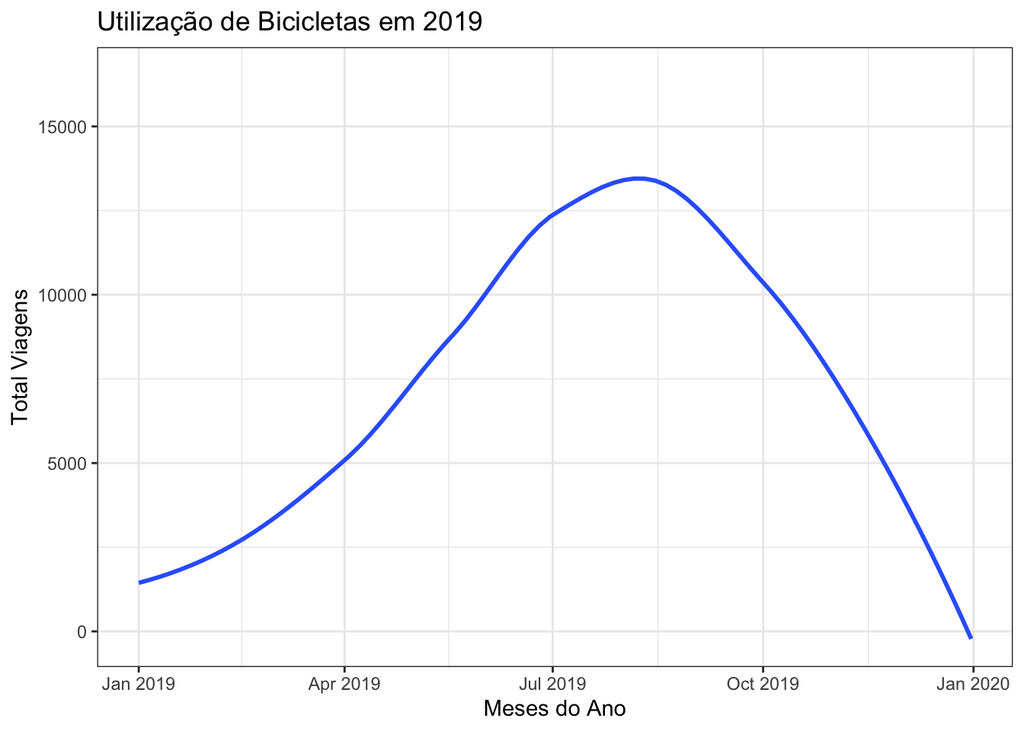

(Gráfico de utilização de bicicletas por mês em 2019.)

**10 estações iniciais mais utilizadas**

```
##        Top 10 Starting Stations Rides
## 1       Streeter Dr & Grand Ave 48589
## 2           Canal St & Adams St 43298
## 3  Clinton St & Washington Blvd 37071
## 4     Lake Shore Dr & Monroe St 35818
## 5       Clinton St & Madison St 35048
## 6  Michigan Ave & Washington St 28948
## 7    Lake Shore Dr & North Blvd 28688
## 8     Columbus Dr & Randolph St 27995
## 9           Theater on the Lake 26643
## 10      Franklin St & Monroe St 26284
```

(Estações de inicio de viagem mais utilizadas em 2019)

**10 estações finais mais utilizadas**

```
##             Top 10 End Stations Rides
## 1       Streeter Dr & Grand Ave 56944
## 2           Canal St & Adams St 39560
## 3  Clinton St & Washington Blvd 38804
## 4    Lake Shore Dr & North Blvd 34131
## 5       Clinton St & Madison St 32566
## 6  Michigan Ave & Washington St 30151
## 7           Theater on the Lake 28625
## 8     Lake Shore Dr & Monroe St 27510
## 9         Michigan Ave & Oak St 26792
## 10              Millennium Park 25774
```

(Estações de fim de viagem mais utilizadas em 2019)

**- Total MA vs MC**

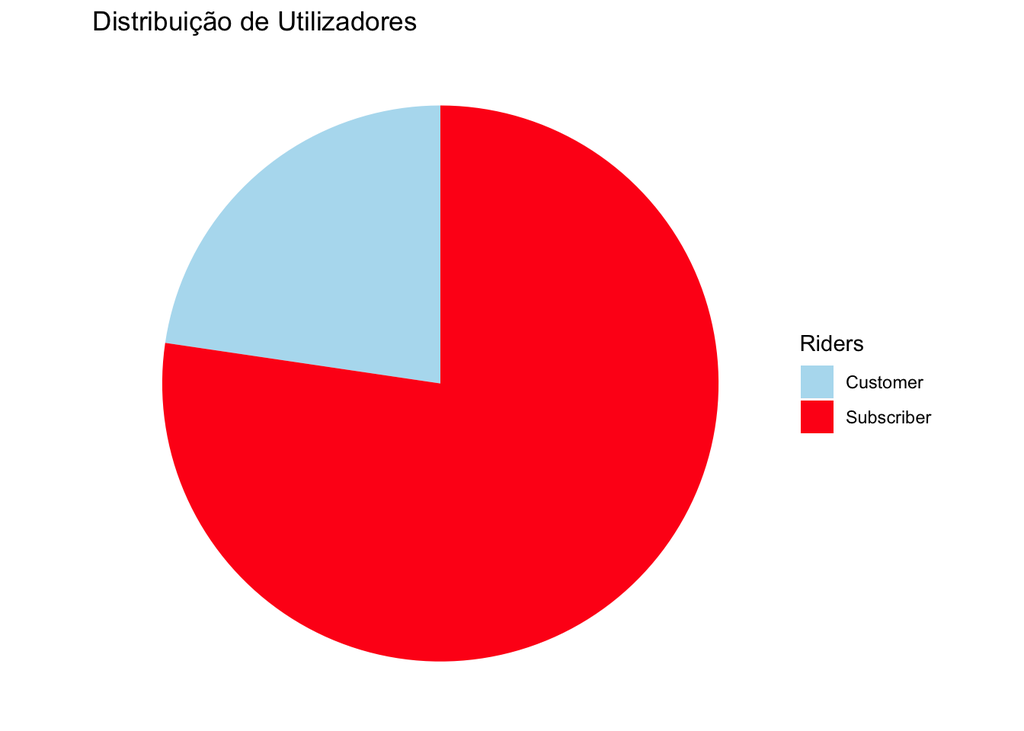

(Tradução: Riders - Ciclistas / Customer - MC’s / Subscriber - MA’s)

**Mais de 3 x assinantes versus casuais**

### DIVVY ASSINANTES

**Vamos observar o subconjunto de assinantes**

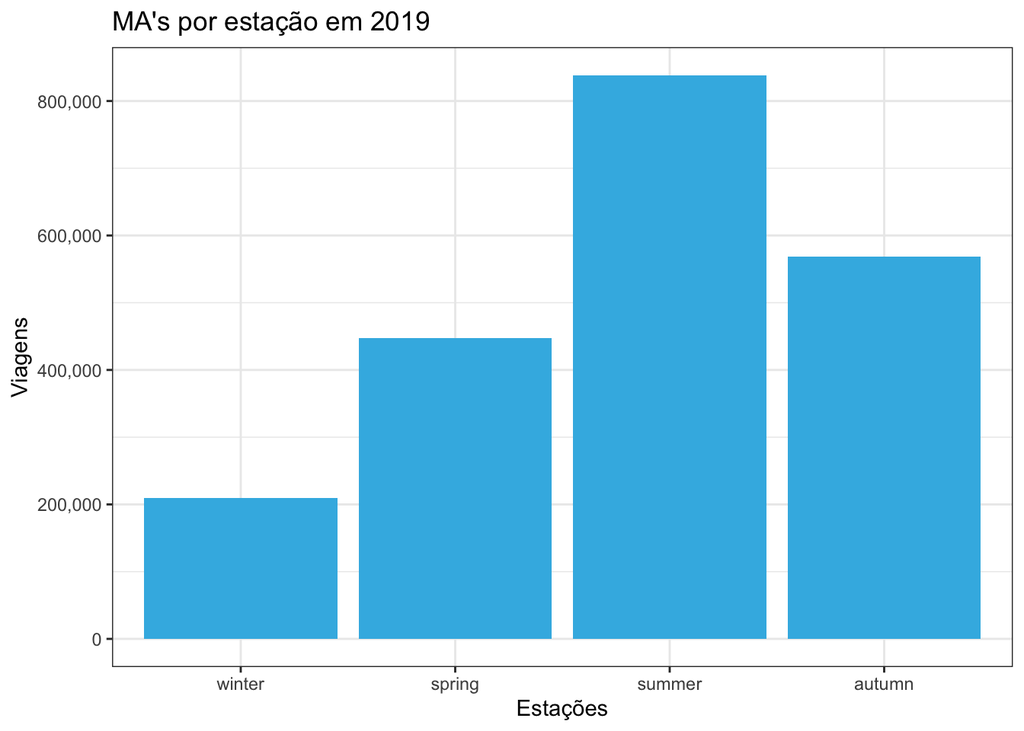

(Tradução: Winter - Inverno / Spring - Primavera / Summer - Verão / Autumn - Outono)

- Como podemos ver no gráfico acima, a tendência original para o verão mantém-se.
- A viagem média em 2019 foi **15.06 minutos** e o tempo mais comum foi **7 minutos.**

**Vejamos a utilização semanal nos meses de verão, pois são a temporada alta**

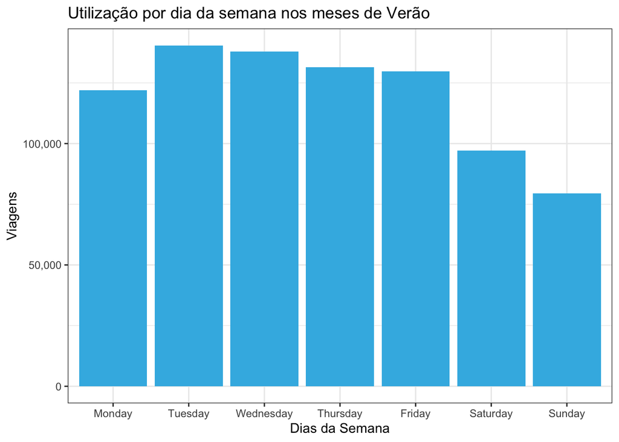

(Tradução - Monday/Tuesday/Wednesday/Thursday/Friday/Saturday/Sunday - Segunda/Terça/Quarta/Quinta/Sexta/Sábado/Domingo)

**É observável uma tendência de queda em direção ao fim de semana. Sendo o Sábado e Domingo menos populares.**

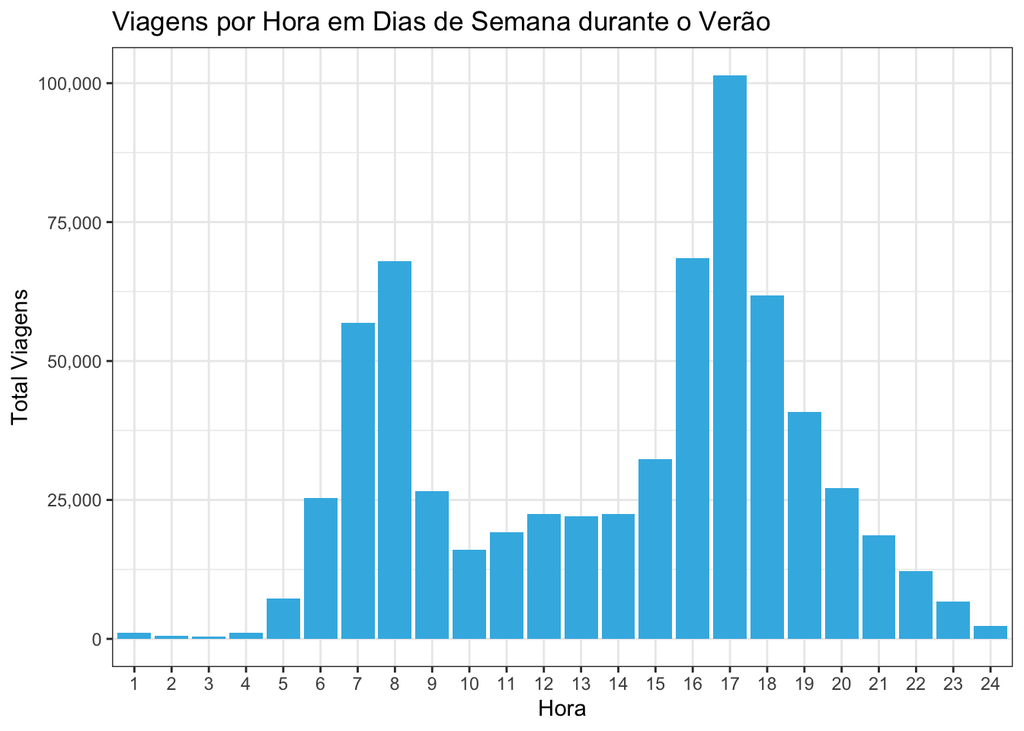

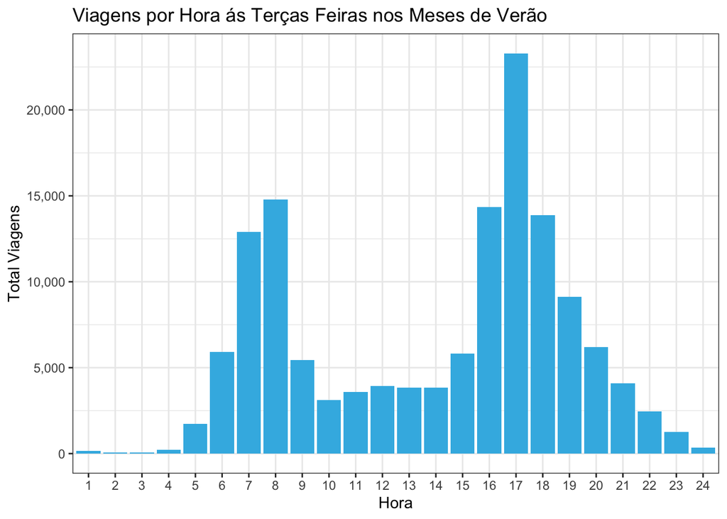

**Observando o uso por hora nos dias de semana e depois às terças-feiras, podemos ver que a hora de ponta, manhã e tarde, é o horário do dia mais usado pelos assinantes.**

### DIVVY CLIENTES CASUAIS

**Vamos prosseguir para os clientes casuais de bicicletas Divvy**

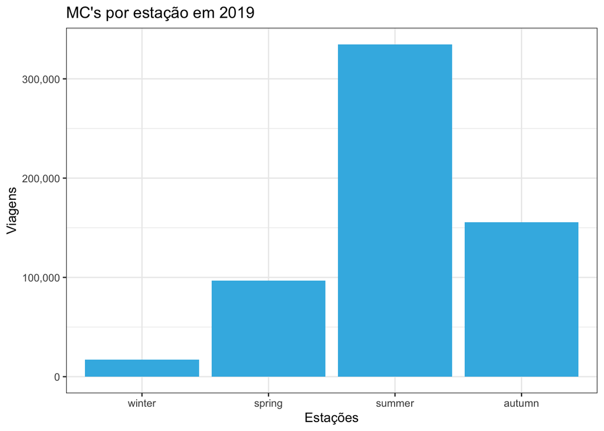

(Tradução: Winter - Inverno / Spring - Primavera / Summer - Verão / Autumn - Outono)

**Neste gráfico podemos ver claramente que a melhor época do ano é novamente os meses de verão**

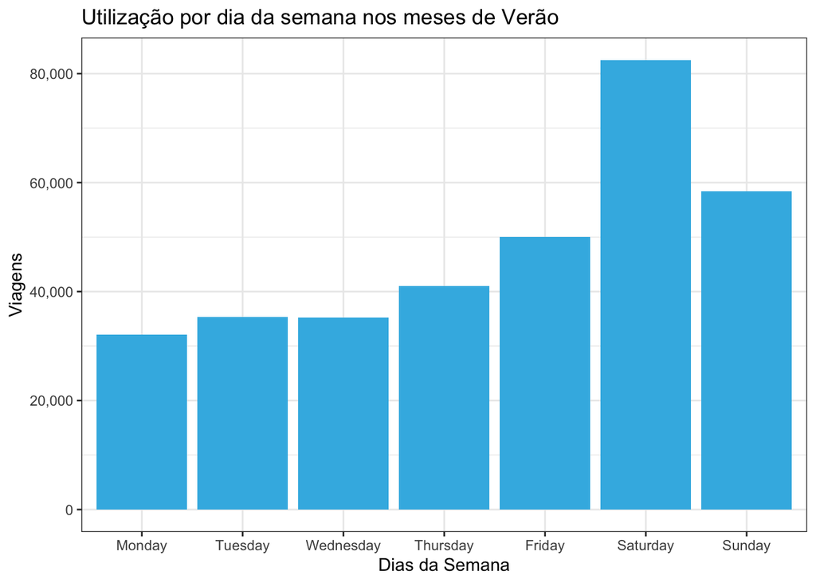

(Tradução - Monday/Tuesday/Wednesday/Thursday/Friday/Saturday/Sunday - Segunda/Terça/Quarta/Quinta/Sexta/Sábado/Domingo)

**Aqui começamos a ver algo diferente, os ciclistas casuais parecem preferir os fins de semana e não os dias de semana.**

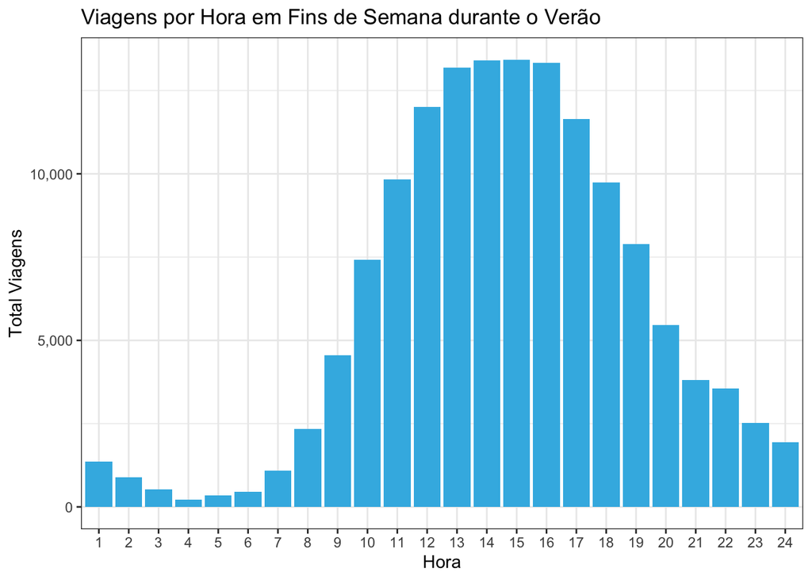

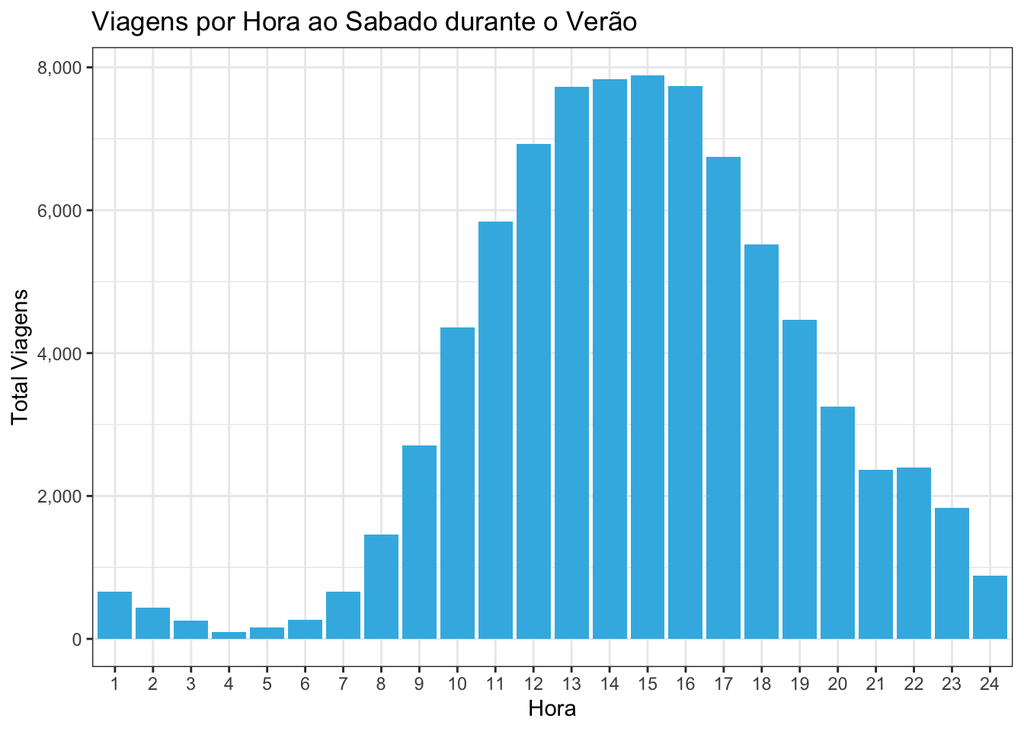

** Aqui podemos ver que eles também preferem horários diferentes do dia quando se trata de pedalar. Os casuais compartilham a hora de ponta, mas viajam a tarde inteira em massa. **

### DIVVY COMPARAÇÃO

**COMO É QUE OS CICLISTAS ASSINANTES SÃO DIFERENTES DOS CASUAIS?**

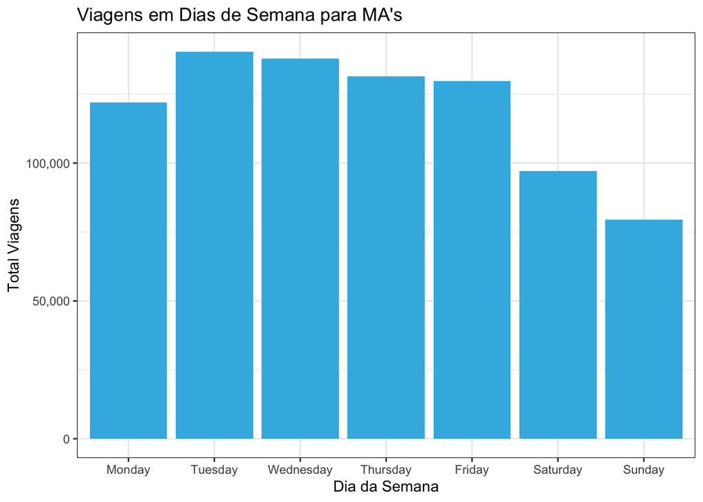

(Tradução - Monday/Tuesday/Wednesday/Thursday/Friday/Saturday/Sunday - Segunda/Terça/Quarta/Quinta/Sexta/Sábado/Domingo)

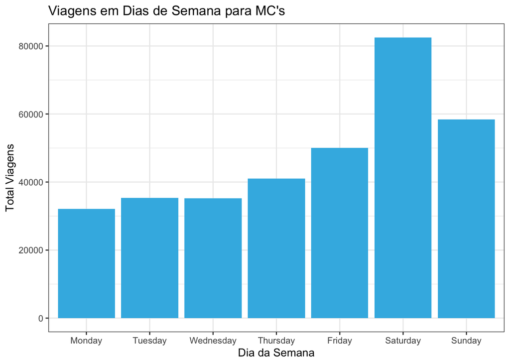

(Tradução - Monday/Tuesday/Wednesday/Thursday/Friday/Saturday/Sunday - Segunda/Terça/Quarta/Quinta/Sexta/Sábado/Domingo)

**Esta é a nossa primeira descoberta: os assinantes preferem os dias de semana, os casuais preferem os fins de semana.**

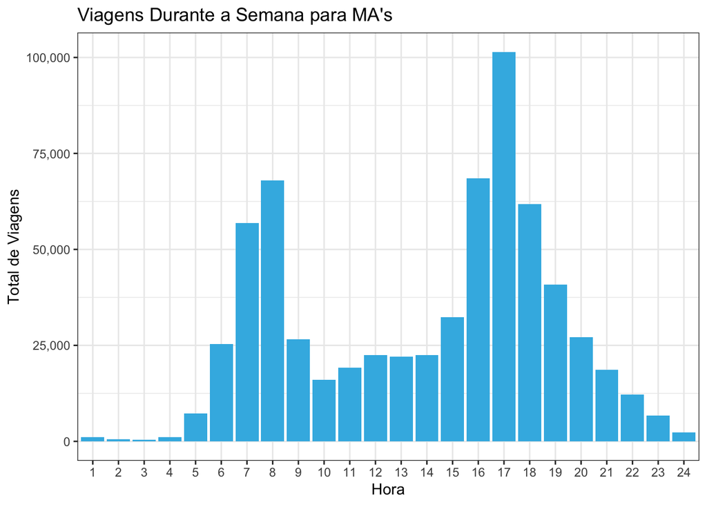

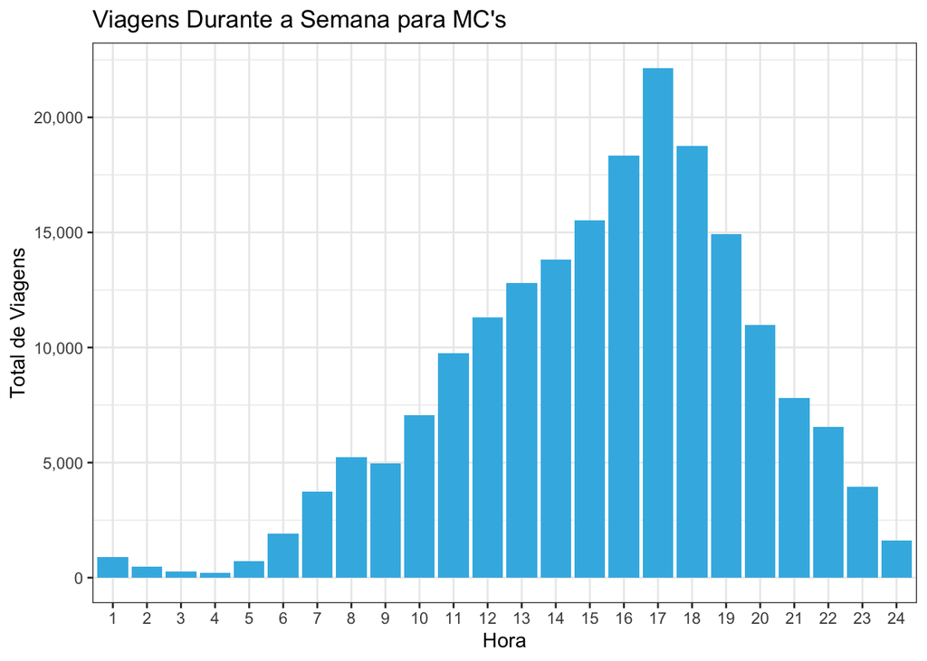

**Esta é a nossa segunda diferença entre eles. Aqui, podemos observar dois picos distintos para assinantes e apenas um unico pico para passageiros casuais.**

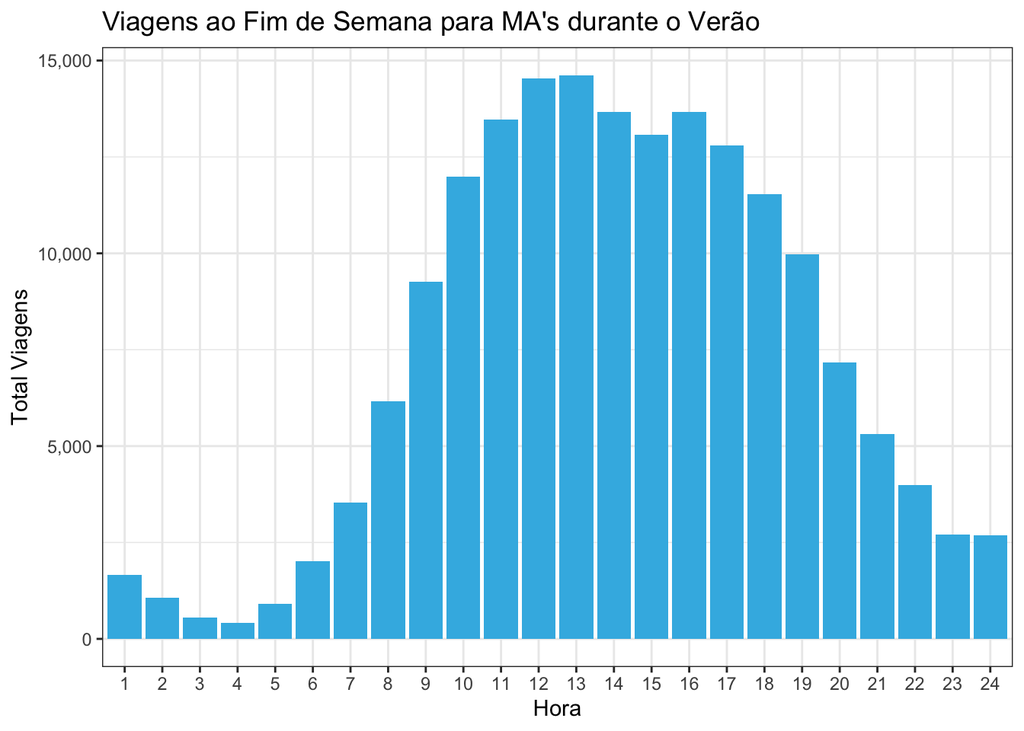

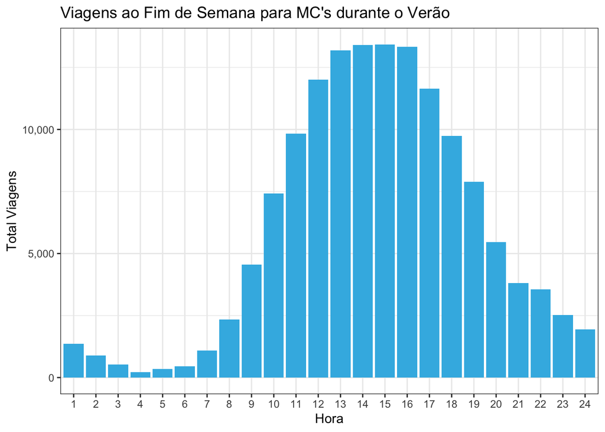

**Mas se olharmos apenas para os fins de semana, podemos dizer que tanto o MA e o MC têm um comportamento idêntico**

Estações Favoritas para MA’s

```
## # A tibble: 10 x 2
##    from_station_name                       n
##    <chr>                               <int>
##  1 Canal St & Adams St                 40344
##  2 Clinton St & Washington Blvd        34827
##  3 Clinton St & Madison St             31895
##  4 Columbus Dr & Randolph St           23568
##  5 Franklin St & Monroe St             23562
##  6 Daley Center Plaza                  23045
##  7 Michigan Ave & Washington St        21463
##  8 Canal St & Madison St               20537
##  9 Kingsbury St & Kinzie St            17834
## 10 Orleans St & Merchandise Mart Plaza 16424
```

Estações Favoritas para MC’s

```
## # A tibble: 10 x 2
##    from_station_name                n
##    <chr>                        <int>
##  1 Streeter Dr & Grand Ave      35776
##  2 Lake Shore Dr & Monroe St    26621
##  3 Shedd Aquarium               15765
##  4 Lake Shore Dr & North Blvd   14707
##  5 Millennium Park              13122
##  6 Michigan Ave & Oak St        12976
##  7 Theater on the Lake          11188
##  8 Adler Planetarium             8754
##  9 Dusable Harbor                8470
## 10 Michigan Ave & Washington St  7485
```

**Em termos de estações, podemos ver também que eles têm suas opções exclusivas.**

### DIVVY QUESTÃO NUMERO 1

**COMO OS ASSINANTES SÃO DIFERENTES DOS CASUAIS?**

Portanto, podemos concluir definitivamente, com base nos dados disponíveis, que os clientes agem de forma diferente, mas apenas quando se trata de dias da semana versus fins de semana. A hora do dia escolhida para pedalar é outra das divergências entre os dois. Estes dados remetem para a hipótese de que provavelmente existem motivos diferentes para o uso das bicicletas.

Essas são suas principais diferenças. E, claro, como vimos acima, sua escolha de estações também diverge.

### CONCLUSÕES E SUGESTÕES

**COMO PODEMOS TRANSFORMAR CASUAIS EM ASSINANTES?**

Este foi o segundo problema / pergunta a ser respondida. Sendo o mais objectivo possível, os dados mostram alguns aspectos do tipo de ciclista, mas só se pode supor sem investigar o contexto.

Como recomendação seria sair e pesquisar os clientes e descobrir seus motivos pessoais para utilização das bicicletas.

No entanto, podemos dizer (teoricamente) que devido ao pico no verão, poderia-se oferecer um simples passe de verão, de Junho a Agosto.

De seguida temos dois cenários. No primeiro desistiam, no segundo cenário os novos assinantes muito provavelmente renovariam. E isto claro se tivermos em conta que a tendência de utilização no verão estende-se bem até ao final do Outono.

É por isso que, após o Passe Especial de Verão, seria oferecida uma assinatura de um ano inteiro pelos próximos 9 meses com um desconto especial equivalente ao o que já havia pago pelo Passe Especial de Verão.

Nessa lógica, primeiro fariam um “test drive” e depois teriam um suposto desconto de 25% na decisão de ficar porque o Outono ainda dá um belo passeio em Chicago.

Outras etapas podem ser tomadas em estudos adicionais se mais dados forem disponibilizados.

Se for verdade (baseado em dados), uma pessoa seria mais saudável só por andar de bicicleta 15 minutos em média por dia.

Poder-se-ia dizer aos empregadores da área, apoiem e ofereçam Subscrições Divvy aos vossos funcionários e eles ficarão menos ausentes do trabalho porque a sua saúde melhoraria e assim poupariam dinheiro.

Fazendo campanha para as pessoas que, ao se inscreverem em divvy e usando, elas seriam mais saudáveis, ajudariam o planeta, teriam melhores verões e inverno e economizariam nas próprias contas de saúde. Uma situação vantajosa para todos.

## ANTES DE TERMINAR

**UMA NOTA SOBRE O PROJETO**

Assim como na primeira apresentação preliminar, gostaria de encerrar com algumas notas sobre o projeto e um agradecimento.

Desta vez, gostaria de dirigir meus sinceros agradecimentos ao “Professor (Instrutor) Charles Lanfear” da Universidade de Washington.

Suas palestras disponibilizadas por ele através do [YouTube Chanel](https://www.youtube.com/channel/UC9o3UMJwzKDMmvo6lh_ppiA/featured) mudaram e ajudaram muito o meu código e a minha compreensão.

Isso é notável no meu código disponível na secção de apêndice.

Qual é a minha opinião sobre tudo isto.

- Preciso praticar e estudar mais quando se trata de Programação em R.
- Minha experiência em estatísticas não é suficiente, mesmo que o núcleo deva ser deixado para os Cientista de Dados, um Analista de Dados precisa saber mais do que o básico, é um requisito.

Para onde irei a partir daqui:

- Bem! Mais projetos com certeza.
- A estatística é outra das disciplinas que necessito de aprofundar.